# Bevan Joubert

### Project - MovieLens Data Analysis

The GroupLens Research Project is a research group in the Department of Computer Science and Engineering at the University of Minnesota. The data is widely used for collaborative filtering and other filtering solutions. However, we will be using this data to act as a means to demonstrate our skill in using Python to “play” with data.

#### Domain

Internet and Entertainment

**Note that the project will need you to apply the concepts of groupby and merging extensively.**

# 1. Import the necessary packages - 2.5 marks

```python
import numpy as np
import pandas as pd
import matplotlib.pyplot as plt
import seaborn as sns
#%matplotlib inline # No need for this line in Jupyter notebook.
```

# 2. Read the 3 datasets into dataframes - 2.5 marks

### Read the datasets from the .csv files into DataFrame objects.

```python
# Read the datasets from .csv files to DataFrames.
data = pd.read_csv("data.csv")
item = pd.read_csv("item.csv")
user = pd.read_csv("user.csv")
```

### View the first 5 columns of each dataset to become more familiar with what data has been recored.

```python
data.head()
```

|  | user id | movie id | rating | timestamp |
| --- | --- | --- | --- | --- |
| 0 | 196 | 242 | 3 | 881250949 |
| 1 | 186 | 302 | 3 | 891717742 |
| 2 | 22 | 377 | 1 | 878887116 |
| 3 | 244 | 51 | 2 | 880606923 |
| 4 | 166 | 346 | 1 | 886397596 |

```python
item.head()
```

|  | movie id | movie title | release date | unknown | Action | Adventure | Animation | Childrens | Comedy | Crime | ... | Fantasy | Film-Noir | Horror | Musical | Mystery | Romance | Sci-Fi | Thriller | War | Western |
| --- | --- | --- | --- | --- | --- | --- | --- | --- | --- | --- | --- | --- | --- | --- | --- | --- | --- | --- | --- | --- | --- |
| 0 | 1 | Toy Story | 01-Jan-1995 | 0 | 0 | 0 | 1 | 1 | 1 | 0 | ... | 0 | 0 | 0 | 0 | 0 | 0 | 0 | 0 | 0 | 0 |
| 1 | 2 | GoldenEye | 01-Jan-1995 | 0 | 1 | 1 | 0 | 0 | 0 | 0 | ... | 0 | 0 | 0 | 0 | 0 | 0 | 0 | 1 | 0 | 0 |
| 2 | 3 | Four Rooms | 01-Jan-1995 | 0 | 0 | 0 | 0 | 0 | 0 | 0 | ... | 0 | 0 | 0 | 0 | 0 | 0 | 0 | 1 | 0 | 0 |
| 3 | 4 | Get Shorty | 01-Jan-1995 | 0 | 1 | 0 | 0 | 0 | 1 | 0 | ... | 0 | 0 | 0 | 0 | 0 | 0 | 0 | 0 | 0 | 0 |
| 4 | 5 | Copycat | 01-Jan-1995 | 0 | 0 | 0 | 0 | 0 | 0 | 1 | ... | 0 | 0 | 0 | 0 | 0 | 0 | 0 | 1 | 0 | 0 |

5 rows × 22 columns

```python
user.head()
```

|  | user id | age | gender | occupation | zip code |
| --- | --- | --- | --- | --- | --- |
| 0 | 1 | 24 | M | technician | 85711 |
| 1 | 2 | 53 | F | other | 94043 |
| 2 | 3 | 23 | M | writer | 32067 |
| 3 | 4 | 24 | M | technician | 43537 |
| 4 | 5 | 33 | F | other | 15213 |

# 3. Apply info, shape, describe, and find the number of missing values in the data - 5 marks

Firstly analyse each dataframe separately because we do not know if they can be combined successfully yet.

### For the 'data.csv' data.

```python
data.info()
```

```
<class 'pandas.core.frame.DataFrame'>
RangeIndex: 100000 entries, 0 to 99999
Data columns (total 4 columns):
user id      100000 non-null int64
movie id     100000 non-null int64
rating       100000 non-null int64
timestamp    100000 non-null int64
dtypes: int64(4)
memory usage: 3.1 MB
```

```python
data.shape
```

```
(100000, 4)
```

```python
data.describe()
```

|  | user id | movie id | rating | timestamp |
| --- | --- | --- | --- | --- |
| count | 100000.00000 | 100000.000000 | 100000.000000 | 1.000000e+05 |
| mean | 462.48475 | 425.530130 | 3.529860 | 8.835289e+08 |
| std | 266.61442 | 330.798356 | 1.125674 | 5.343856e+06 |
| min | 1.00000 | 1.000000 | 1.000000 | 8.747247e+08 |
| 25% | 254.00000 | 175.000000 | 3.000000 | 8.794487e+08 |
| 50% | 447.00000 | 322.000000 | 4.000000 | 8.828269e+08 |
| 75% | 682.00000 | 631.000000 | 4.000000 | 8.882600e+08 |
| max | 943.00000 | 1682.000000 | 5.000000 | 8.932866e+08 |

```python
data.isnull().sum()
```

```
user id      0
movie id     0
rating       0
timestamp    0
dtype: int64
```

### For the 'item.csv' data.

```python
item.info()
```

```
<class 'pandas.core.frame.DataFrame'>
RangeIndex: 1681 entries, 0 to 1680
Data columns (total 22 columns):
movie id        1681 non-null int64
movie title     1681 non-null object
release date    1681 non-null object
unknown         1681 non-null int64
Action          1681 non-null int64
Adventure       1681 non-null int64
Animation       1681 non-null int64
Childrens       1681 non-null int64
Comedy          1681 non-null int64
Crime           1681 non-null int64
Documentary     1681 non-null int64
Drama           1681 non-null int64
Fantasy         1681 non-null int64
Film-Noir       1681 non-null int64
Horror          1681 non-null int64
Musical         1681 non-null int64
Mystery         1681 non-null int64
Romance         1681 non-null int64
Sci-Fi          1681 non-null int64
Thriller        1681 non-null int64
War             1681 non-null int64
Western         1681 non-null int64
dtypes: int64(20), object(2)
memory usage: 289.0+ KB
```

```python
item.shape
```

```
(1681, 22)
```

```python
item.describe()
```

|  | movie id | unknown | Action | Adventure | Animation | Childrens | Comedy | Crime | Documentary | Drama | Fantasy | Film-Noir | Horror | Musical | Mystery | Romance | Sci-Fi | Thriller | War | Western |
| --- | --- | --- | --- | --- | --- | --- | --- | --- | --- | --- | --- | --- | --- | --- | --- | --- | --- | --- | --- | --- |
| count | 1681.000000 | 1681.000000 | 1681.000000 | 1681.000000 | 1681.000000 | 1681.000000 | 1681.000000 | 1681.000000 | 1681.000000 | 1681.000000 | 1681.000000 | 1681.000000 | 1681.000000 | 1681.000000 | 1681.000000 | 1681.000000 | 1681.000000 | 1681.000000 | 1681.000000 | 1681.000000 |
| mean | 841.841761 | 0.000595 | 0.149316 | 0.080309 | 0.024985 | 0.072576 | 0.300416 | 0.064842 | 0.029744 | 0.431291 | 0.013087 | 0.014277 | 0.054729 | 0.033314 | 0.036288 | 0.146936 | 0.060083 | 0.149316 | 0.042237 | 0.016062 |
| std | 485.638077 | 0.024390 | 0.356506 | 0.271852 | 0.156126 | 0.259516 | 0.458576 | 0.246321 | 0.169931 | 0.495404 | 0.113683 | 0.118667 | 0.227519 | 0.179507 | 0.187061 | 0.354148 | 0.237712 | 0.356506 | 0.201189 | 0.125751 |
| min | 1.000000 | 0.000000 | 0.000000 | 0.000000 | 0.000000 | 0.000000 | 0.000000 | 0.000000 | 0.000000 | 0.000000 | 0.000000 | 0.000000 | 0.000000 | 0.000000 | 0.000000 | 0.000000 | 0.000000 | 0.000000 | 0.000000 | 0.000000 |
| 25% | 422.000000 | 0.000000 | 0.000000 | 0.000000 | 0.000000 | 0.000000 | 0.000000 | 0.000000 | 0.000000 | 0.000000 | 0.000000 | 0.000000 | 0.000000 | 0.000000 | 0.000000 | 0.000000 | 0.000000 | 0.000000 | 0.000000 | 0.000000 |
| 50% | 842.000000 | 0.000000 | 0.000000 | 0.000000 | 0.000000 | 0.000000 | 0.000000 | 0.000000 | 0.000000 | 0.000000 | 0.000000 | 0.000000 | 0.000000 | 0.000000 | 0.000000 | 0.000000 | 0.000000 | 0.000000 | 0.000000 | 0.000000 |
| 75% | 1262.000000 | 0.000000 | 0.000000 | 0.000000 | 0.000000 | 0.000000 | 1.000000 | 0.000000 | 0.000000 | 1.000000 | 0.000000 | 0.000000 | 0.000000 | 0.000000 | 0.000000 | 0.000000 | 0.000000 | 0.000000 | 0.000000 | 0.000000 |
| max | 1682.000000 | 1.000000 | 1.000000 | 1.000000 | 1.000000 | 1.000000 | 1.000000 | 1.000000 | 1.000000 | 1.000000 | 1.000000 | 1.000000 | 1.000000 | 1.000000 | 1.000000 | 1.000000 | 1.000000 | 1.000000 | 1.000000 | 1.000000 |

```python
item.isnull().sum()
```

```
movie id        0
movie title     0
release date    0
unknown         0
Action          0
Adventure       0
Animation       0
Childrens       0
Comedy          0
Crime           0
Documentary     0
Drama           0
Fantasy         0
Film-Noir       0
Horror          0
Musical         0
Mystery         0
Romance         0
Sci-Fi          0
Thriller        0
War             0
Western         0
dtype: int64
```

### For the 'user.csv' data.

```python
user.info()
```

```
<class 'pandas.core.frame.DataFrame'>
RangeIndex: 943 entries, 0 to 942
Data columns (total 5 columns):
user id       943 non-null int64
age           943 non-null int64
gender        943 non-null object
occupation    943 non-null object
zip code      943 non-null object
dtypes: int64(2), object(3)
memory usage: 37.0+ KB
```

```python
user.shape
```

```
(943, 5)
```

```python
user.describe()
```

|  | user id | age |
| --- | --- | --- |
| count | 943.000000 | 943.000000 |
| mean | 472.000000 | 34.051962 |
| std | 272.364951 | 12.192740 |
| min | 1.000000 | 7.000000 |
| 25% | 236.500000 | 25.000000 |
| 50% | 472.000000 | 31.000000 |
| 75% | 707.500000 | 43.000000 |
| max | 943.000000 | 73.000000 |

```python
user.isnull().sum()
```

```
user id       0
age           0
gender        0
occupation    0
zip code      0
dtype: int64
```

# 4. Find the number of movies per genre using the item data - 5 marks

```python
# use sum on the default axis
item.drop(columns=['movie id', 'movie title', 'release date']).sum()
```

```
unknown          1
Action         251
Adventure      135
Animation       42
Childrens      122
Comedy         505
Crime          109
Documentary     50
Drama          725
Fantasy         22
Film-Noir       24
Horror          92
Musical         56
Mystery         61
Romance        247
Sci-Fi         101
Thriller       251
War             71
Western         27
dtype: int64
```

# 5. Find the movies that have more than one genre - 2.5 marks

```python
# Drop the columns which are not required.
categories= item.drop(columns=['release date'])
# Set the 'movie id' and 'movie title' as the index so that they don't get summed.
categories.set_index(['movie id', 'movie title'], inplace=True)
# Sum along each row, this will create a Series.
summedCategories = categories.sum(axis=1)
# If a value in this series is larger than 1, it means the move had more than 1 category. Extract such movies.
multiCategory = summedCategories[summedCategories>1]

print("There are {:d} movies which have multiple categories, these are: ".format(multiCategory.count()))
multiCategory
```

```
There are 849 movies which have multiple categories, these are:
```

```
movie id  movie title
1         Toy Story             3
2         GoldenEye             3
4         Get Shorty            3
5         Copycat               3
7         Twelve Monkeys        2
                               ..
1669      MURDER and murder     3
1670      Tainted               2
1673      Mirage                2
1679      B. Monkey             2
1680      Sliding Doors         2
Length: 849, dtype: int64
```

# 6. Drop the movie where the genre is unknown - 2.5 marks

```python
# Confirm the number of movies with genre unknown.
item[item['unknown']>0]['unknown'].count()
```

```
1
```

```python
# Check the current size of the dataframe.
item.shape
```

```
(1681, 22)
```

```python
# Drop the row where the 'unknown' column has a value of 1.
item.drop(index=item[item['unknown']==1].index, inplace=True)
# Confirm that a row has been dropped.
item.shape
```

```
(1680, 22)
```

```python
# Confirm that there are no more items with 'unknown' genre.
item[item['unknown']>0]['unknown'].count()
```

```
0
```

```python
# Any further analysis will continue with this version of the item dataset unless otherwise stated.
```

# 7. Univariate plots of columns: 'rating', 'Age', 'release year', 'Gender' and 'Occupation' - 10 marks

```python
# HINT: use distplot for age and countplot for gender,ratings,occupation.
# HINT: Please refer to the below snippet to understand how to get to release year from release date. You can use str.split()
# as depicted below
# Hint : Use displot without kde for release year or line plot showing year wise count.
```

```python
a = 'My*cat*is*brown'
print(a.split('*')[3])

#similarly, the release year needs to be taken out from release date

#also you can simply slice existing string to get the desired data, if we want to take out the colour of the cat

print(a[10:])
print(a[-5:])
```

```
brown
brown
brown
```

```python
#your answers here
```

### Distribution of user age.

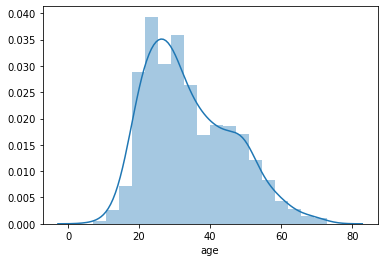

```python
# Distribution of user age.
sns.distplot(user['age'])
```

### Histogram of user gender.

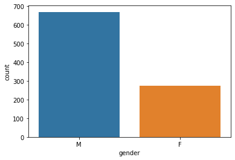

```python
# Histogram of user genders.
sns.countplot(user['gender'])
```

### Histogram of user occupation.

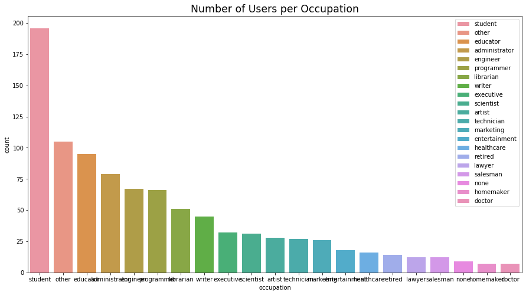

```python
# Histogram of user occupations.
# All we need for this plot is:
#sns.countplot(user['occupation'], order=occupationCount['occupation'])
# I have done some additional pre and post processing to create a graph which is easy to read.

# First sort the data by number of users per occupation, in descending order.
occupationCount = pd.DataFrame(user.groupby('occupation')['occupation'].count().sort_values(ascending=False))
occupationCount.rename(columns={'occupation':'count'}, inplace=True)
occupationCount.reset_index(inplace=True)
# Now plot the data.
plt.figure(figsize=(15,8))
# Here comes the money maker.
ax = sns.countplot(user['occupation'], order=occupationCount['occupation'], label=occupationCount['occupation'])
plt.title("Number of Users per Occupation", fontsize="xx-large")
# xticklabels merge and are hard to read, so add a legend to display the occupations more clearly.
xTickLabels = ax.get_xticklabels()
labels = list(l.get_text() for l in xTickLabels)
handles = [p for p in ax.patches]
plt.legend(handles, labels)
```

### Histogram of ratings.

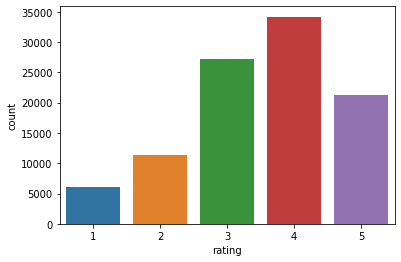

```python
# Histogram of ratings.
sns.countplot(data['rating'])
```

### Histogram of amount of movies released per year.

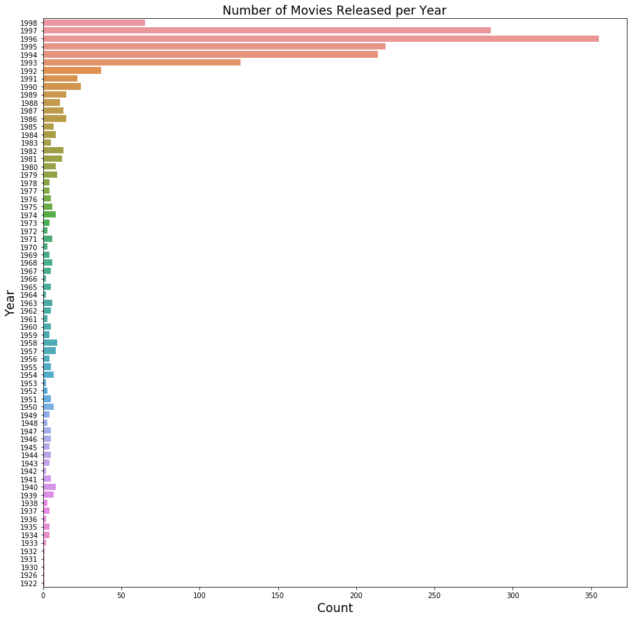

```python
# Histogram of movies released per year.
# This question can be completed with only the following:
#sns.countplot([year.split('-')[2] for year in item['release date']])
# But that would be very difficult to read. Extra processing is done to make the graph more readable.

# First extract the year from the 'release date' column.
yearCount = pd.DataFrame([year.split('-')[2] for year in item['release date']])
yearCount.rename(columns={0:'year'}, inplace=True)
# The yearCount['year'] Series will be used to specify the order of the plot, so sort the year value accordingly.
yearCount['counter'] = [1 for y in yearCount['year']]
yearCount = yearCount.groupby('year').count().sort_values(by='year', ascending=False) # Could use sum() as well since the counter column contains only 1's
yearCount.reset_index(inplace=True)

# Plot the figure vertically to all years to be readable.
plt.figure(figsize=(15,15))
ax = sns.countplot(y=0, data=pd.DataFrame([year.split('-')[2] for year in item['release date']]), order=yearCount['year'], label=yearCount['year'])
plt.title("Number of Movies Released per Year", fontsize='xx-large')
plt.ylabel("Year", fontsize='xx-large')
plt.xlabel("Count", fontsize='xx-large')
print()
```

# 8. Visualize how popularity of genres has changed over the years - 10 marks

Note that you need to use the number of releases in a year as a parameter of popularity of a genre

Hint

1: you need to reach to a data frame where the release year is the index and the genre is the column names (one cell shows the number of release in a year in one genre) or vice versa. Once that is achieved, you can either use univariate plots or can use the heatmap to visualise all the changes over the years in one go.

Hint 2: Use groupby on the relevant column and use sum() on the same to find out the nuumber of releases in a year/genre.

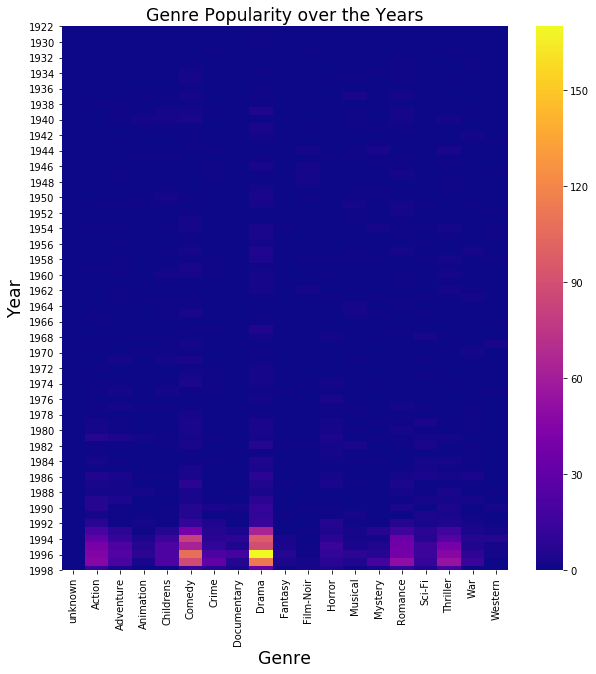

```python
# First create a ne dataframe with the 'year' extracted from the 'release date'
item2 = item.copy()
item2['release date'] = item2['release date'].apply(lambda x : x.split('-')[2])
item2.rename(columns={'release date':'year'}, inplace=True)
item2.drop(columns=['movie id', 'movie title'], inplace=True)
item2.set_index('year', inplace=True)
genrePerYear = item2.groupby('year').sum().sort_values(by='year')
plt.figure(figsize=(10,10))
sns.heatmap(genrePerYear, cmap='plasma')
plt.title("Genre Popularity over the Years", fontsize='xx-large')
plt.xlabel("Genre", fontsize='xx-large')
plt.ylabel("Year", fontsize='xx-large')
print()
```

### Comparing the data like this is not a good comparison, because the amount of movies made per year differ greatly. If we normalise the data by dividing the total number of films in each genre for a year by the total amount of films released in the year, then it may give a better representation of how popular each genre was in that year.

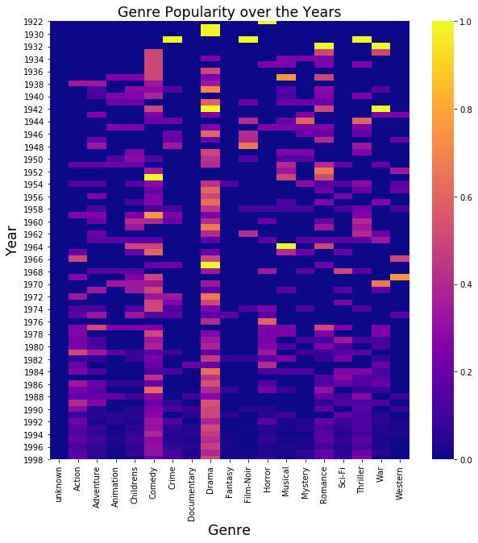

```python
# yearCount was created in question 7, it contains the amount of movies made per year.
genrePerYearDiv = genrePerYear.div(pd.Series(list(yearCount['counter']), index=yearCount.set_index('year').index), axis='index')
genrePerYearDiv
plt.figure(figsize=(10,10))
sns.heatmap(genrePerYearDiv, cmap='plasma')
plt.title("Genre Popularity over the Years", fontsize='xx-large')
plt.xlabel("Genre", fontsize='xx-large')
plt.ylabel("Year", fontsize='xx-large')
print()
```

### The Drama genre seems to have withstood the test of time.

### 9. Find the top 25 movies, each having a minimum of 100 ratings - 10 marks

Hint :

1. First find the movies that have more than 100 ratings(use merge, groupby and count). Extract the movie titles in a list.
2. Find the average rating of all the movies and sort them in the descending order. You will have to use the .merge() function to reach to a data set through which you can get the names and the average rating.
3. Use isin(list obtained from 1) to filter out the movies which have more than 100 ratings.

Note: This question will need you to research about groupby and apply your findings. You can find more on groupby on https://realpython.com/pandas-groupby/.

```python
# First merge data and item to get a DataFrame which contains 'movie title' and 'rating'.
movieRatings = pd.merge(data, item, how='outer', on='movie id')
# Check that the 2 dataframes had corresponding values for all entrie.
print(movieRatings.shape)
movieRatings.isnull().sum()
```

```
(100000, 25)
```

```
user id          0
movie id         0
rating           0
timestamp        0
movie title     10
release date    10
unknown         10
Action          10
Adventure       10
Animation       10
Childrens       10
Comedy          10
Crime           10
Documentary     10
Drama           10
Fantasy         10
Film-Noir       10
Horror          10
Musical         10
Mystery         10
Romance         10
Sci-Fi          10
Thriller        10
War             10
Western         10
dtype: int64
```

```python
# There are some rows with null values, lets print them.
movieRatings[movieRatings['War'].isnull()]
```

|  | user id | movie id | rating | timestamp | movie title | release date | unknown | Action | Adventure | Animation | ... | Fantasy | Film-Noir | Horror | Musical | Mystery | Romance | Sci-Fi | Thriller | War | Western |
| --- | --- | --- | --- | --- | --- | --- | --- | --- | --- | --- | --- | --- | --- | --- | --- | --- | --- | --- | --- | --- | --- |
| 84856 | 130 | 267 | 5 | 875801239 | NaN | NaN | NaN | NaN | NaN | NaN | ... | NaN | NaN | NaN | NaN | NaN | NaN | NaN | NaN | NaN | NaN |
| 84857 | 5 | 267 | 4 | 875635064 | NaN | NaN | NaN | NaN | NaN | NaN | ... | NaN | NaN | NaN | NaN | NaN | NaN | NaN | NaN | NaN | NaN |
| 84858 | 268 | 267 | 3 | 875742077 | NaN | NaN | NaN | NaN | NaN | NaN | ... | NaN | NaN | NaN | NaN | NaN | NaN | NaN | NaN | NaN | NaN |
| 84859 | 297 | 267 | 3 | 875409139 | NaN | NaN | NaN | NaN | NaN | NaN | ... | NaN | NaN | NaN | NaN | NaN | NaN | NaN | NaN | NaN | NaN |
| 84860 | 319 | 267 | 4 | 875707690 | NaN | NaN | NaN | NaN | NaN | NaN | ... | NaN | NaN | NaN | NaN | NaN | NaN | NaN | NaN | NaN | NaN |
| 84861 | 1 | 267 | 4 | 875692955 | NaN | NaN | NaN | NaN | NaN | NaN | ... | NaN | NaN | NaN | NaN | NaN | NaN | NaN | NaN | NaN | NaN |
| 84862 | 532 | 267 | 3 | 875441348 | NaN | NaN | NaN | NaN | NaN | NaN | ... | NaN | NaN | NaN | NaN | NaN | NaN | NaN | NaN | NaN | NaN |
| 84863 | 833 | 267 | 1 | 875655669 | NaN | NaN | NaN | NaN | NaN | NaN | ... | NaN | NaN | NaN | NaN | NaN | NaN | NaN | NaN | NaN | NaN |
| 84864 | 422 | 267 | 4 | 875655986 | NaN | NaN | NaN | NaN | NaN | NaN | ... | NaN | NaN | NaN | NaN | NaN | NaN | NaN | NaN | NaN | NaN |
| 97491 | 181 | 1373 | 1 | 878962052 | NaN | NaN | NaN | NaN | NaN | NaN | ... | NaN | NaN | NaN | NaN | NaN | NaN | NaN | NaN | NaN | NaN |

10 rows × 25 columns

```python
# There are ratings for movies in 'data' that do not have corresponding entries in 'item'.
# These will not have an effect on the outcome of this question, but drop them anyway by doing an inner merge.
# First merge data and item to get a DataFrame which contains 'movie title' and 'rating'.
movieRatings = pd.merge(data, item, how='inner', on='movie id')
# Check that the 2 dataframes had corresponding values for all entrie.
print(movieRatings.shape)
movieRatings.isnull().sum()
```

```
(99990, 25)
```

```
user id         0
movie id        0
rating          0
timestamp       0
movie title     0
release date    0
unknown         0
Action          0
Adventure       0
Animation       0
Childrens       0
Comedy          0
Crime           0
Documentary     0
Drama           0
Fantasy         0
Film-Noir       0
Horror          0
Musical         0
Mystery         0
Romance         0
Sci-Fi          0
Thriller        0
War             0
Western         0
dtype: int64
```

```
The top 25 movies with more 100 or more ratings are:
                                                      rating
movie title
Close Shave, A                                      4.491071
Schindler's List                                    4.466443
Wrong Trousers, The                                 4.466102
Casablanca                                          4.456790
Shawshank Redemption, The                           4.445230
Rear Window                                         4.387560
Usual Suspects, The                                 4.385768
Star Wars                                           4.358491
12 Angry Men                                        4.344000
Citizen Kane                                        4.292929
To Kill a Mockingbird                               4.292237
One Flew Over the Cuckoo's Nest                     4.291667
Silence of the Lambs, The                           4.289744
North by Northwest                                  4.284916
Godfather, The                                      4.283293
Secrets & Lies                                      4.265432
Good Will Hunting                                   4.262626
Manchurian Candidate, The                           4.259542
Dr. Strangelove or: How I Learned to Stop Worry...  4.252577
Raiders of the Lost Ark                             4.252381
Vertigo                                             4.251397
Titanic                                             4.245714
Lawrence of Arabia                                  4.231214
Maltese Falcon, The                                 4.210145
Empire Strikes Back, The                            4.204360
```

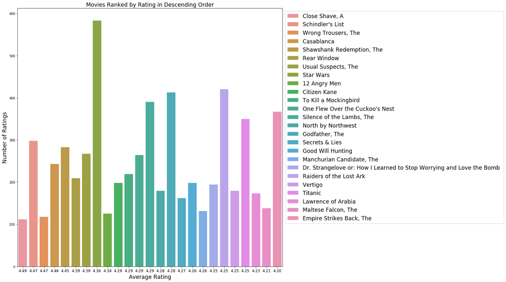

```python
# Now we can continue to answer the question.
# Just recreate the DataFrame so that Python does not cry each time the cell is re-run.
movieRatings = pd.merge(data, item, how='inner', on='movie id')
# We only need 'movie title' and 'rating'.
movieRatings = movieRatings[['movie title', 'rating']]
# Get a list containing the movies with more than 100 ratings.
moviesWithMoreThan100Ratings = movieRatings.groupby('movie title').count()
moviesWithMoreThan100Ratings.rename(columns={'rating':'count'}, inplace=True)
moviesWithMoreThan100Ratings = moviesWithMoreThan100Ratings[moviesWithMoreThan100Ratings['count'] >= 100]
moviesWithMoreThan100Ratings.reset_index(inplace=True)
moviesWithMoreThan100RatingsList = list(moviesWithMoreThan100Ratings['movie title'])
# Get the average ratings of each of these movies.
movieRatings.set_index('movie title', inplace=True)
movieRatings = movieRatings.loc[moviesWithMoreThan100RatingsList].groupby('movie title').mean().sort_values(by='rating', ascending=False)
# The first 25 movies are the 25 highest rated, since they hav already been sorted.
top25Movies = movieRatings.iloc[0:25]
print("The top 25 movies with more 100 or more ratings are:")
print(top25Movies)
# Just for fun, we can plot a histogram of the top 25 movies and how many ratings they had.
plt.figure(figsize=(15,15))
ax = sns.barplot(np.arange(25), list(moviesWithMoreThan100Ratings.set_index('movie title').loc[top25Movies.index]['count']))
labels = list(top25Movies.index)
handles = [p for p in ax.patches]
plt.legend(handles=handles, labels=labels, loc='upper left', bbox_to_anchor=(1,1), ncol=1, fontsize='xx-large')
plt.title("Movies Ranked by Rating in Descending Order", fontsize='xx-large')
plt.xlabel("Average Rating", fontsize='xx-large')
plt.ylabel("Number of Ratings", fontsize='xx-large')
plt.xticks(np.arange(25), ["{:.2f}".format(r) for r in top25Movies['rating']], fontsize='large')
print()
```

# 10. See gender distribution across different genres check for the validity of the below statements - 10 marks

- Men watch more drama than women
- Women watch more Sci-Fi than men
- Men watch more Romance than women
1. There is no need to conduct statistical tests around this. Just compare the percentages and comment on the validity of the above statements.
2. you might want ot use the .sum(), .div() function here.
3. Use number of ratings to validate the numbers. For example, if out of 4000 ratings received by women, 3000 are for drama, we will assume that 75% of the women watch drama.

### Evaluation

```python
# First get the total amount of ratings for men and women.
# It was determined in the previous question that an inner merge should be done to avoid null values.
userData = pd.merge(user, data, how="inner", on='user id')
userData.groupby('gender').count()
```

| gender | user id | age | occupation | zip code | movie id | rating | timestamp |
| --- | --- | --- | --- | --- | --- | --- | --- |
| F | 25740 | 25740 | 25740 | 25740 | 25740 | 25740 | 25740 |
| M | 74260 | 74260 | 74260 | 74260 | 74260 | 74260 | 74260 |

```python
womenTotalRatings = userData.groupby('gender').count()['user id'][0]
menTotalRatings = userData.groupby('gender').count()['user id'][1]
print("Ther is a total of {:d} ratings by men.".format(menTotalRatings))
print("Ther is a total of {:d} ratings by women.".format(womenTotalRatings))
```

```
Ther is a total of 74260 ratings by men.
Ther is a total of 25740 ratings by women.
```

```python
# Now get the amount of ratings of each gender per genre.
userDataItem = pd.merge(userData, item, how="inner", on="movie id")
# Drop all the columns that aren't needed.
ratingNumbers = userDataItem.drop(labels=['user id', 'age', 'movie id', 'rating', 'timestamp', 'unknown'], axis=1).groupby('gender').sum()
ratingNumbers
```

| gender | Action | Adventure | Animation | Childrens | Comedy | Crime | Documentary | Drama | Fantasy | Film-Noir | Horror | Musical | Mystery | Romance | Sci-Fi | Thriller | War | Western |
| --- | --- | --- | --- | --- | --- | --- | --- | --- | --- | --- | --- | --- | --- | --- | --- | --- | --- | --- |
| F | 5442 | 3141 | 995 | 2232 | 8068 | 1794 | 187 | 11008 | 363 | 385 | 1197 | 1442 | 1314 | 5858 | 2629 | 5086 | 2189 | 371 |
| M | 20147 | 10612 | 2610 | 4950 | 21764 | 6261 | 571 | 28887 | 989 | 1348 | 4120 | 3512 | 3931 | 13603 | 10101 | 16786 | 7209 | 1483 |

```python
# Create the DataFrame to Divide by.
ratingTotals = pd.Series([womenTotalRatings, menTotalRatings], index=['F', 'M'])
ratingTotals
```

```
F    25740
M    74260
dtype: int64
```

```python
# Now calculate the percentage of ratings per category.
ratingPercentages = ratingNumbers.div(ratingTotals, axis='index').mul(100)
ratingPercentages
```

| gender | Action | Adventure | Animation | Childrens | Comedy | Crime | Documentary | Drama | Fantasy | Film-Noir | Horror | Musical | Mystery | Romance | Sci-Fi | Thriller | War | Western |
| --- | --- | --- | --- | --- | --- | --- | --- | --- | --- | --- | --- | --- | --- | --- | --- | --- | --- | --- |
| F | 21.142191 | 12.202797 | 3.865579 | 8.671329 | 31.344211 | 6.969697 | 0.726496 | 42.766123 | 1.410256 | 1.495726 | 4.650350 | 5.602176 | 5.104895 | 22.758353 | 10.213675 | 19.759130 | 8.504274 | 1.441336 |
| M | 27.130353 | 14.290331 | 3.514678 | 6.665769 | 29.307837 | 8.431188 | 0.768920 | 38.899811 | 1.331807 | 1.815244 | 5.548074 | 4.729329 | 5.293563 | 18.318072 | 13.602208 | 22.604363 | 9.707783 | 1.997037 |

### Conclusion:

```python
print("Statement: 'Men watch more drama than women'")
print("{:.2f}% of men watch drama.".format(ratingPercentages.loc['M','Drama']))
print("{:.2f}% of women watch drama.".format(ratingPercentages.loc['F','Drama']))
print("Therefore, this statement is INCORRECT.")
```

```
Statement: 'Men watch more drama than women'
38.90% of men watch drama.
42.77% of women watch drama.
Therefore, this statement is INCORRECT.
```

```python
print("Statement: 'Women watch more Sci-Fi than men'")
print("{:.2f}% of men watch Sci-Fi.".format(ratingPercentages.loc['M','Sci-Fi']))
print("{:.2f}% of women watch Sci-Fi.".format(ratingPercentages.loc['F','Sci-Fi']))
print("Therefore, this statement is INCORRECT.")
```

```
Statement: 'Women watch more Sci-Fi than men'
13.60% of men watch Sci-Fi.
10.21% of women watch Sci-Fi.
Therefore, this statement is INCORRECT.
```

```python
print("Statement: 'Men watch more Romance than women'")
print("{:.2f}% of men watch Romance.".format(ratingPercentages.loc['M','Romance']))
print("{:.2f}% of women watch Romance.".format(ratingPercentages.loc['F','Romance']))
print("Therefore, this statement is INCORRECT.")
```

```
Statement: 'Men watch more Romance than women'
18.32% of men watch Romance.
22.76% of women watch Romance.
Therefore, this statement is INCORRECT.
```